# Containerisation - docker and singularity

Author

Murray Logan

Published

March 4, 2026

# 1 Background information

In the previous tutorial, we discussed why it is important that your codebase is under version control and backed up to help ensure that your analyses can be evaluated and replicated by you and others both now and into the future. However, having access to the code (and data) does not always guarantee full reproducibility - this can also be effected by the exact software environment in which the code is run.

In the context of statistical analyses performed in R for example, R as well as the various packages that you have elected to use in support your analyses can (and do) evolve over time. Some functions get modified and some even get depreciated. Hence, over time, code that once worked perfectly (or at least adequately) can become *broken*.

Early solutions to this facet of reproducibility focused on **virtual machines**. Virtual machines (VM) build entire software environments on top of a software layer that mimics a physical computer such that each VM runs on a *host* computer is a completely separate self-contained entity. Whilst VMs do permit great flexibility (as virtually any operating system can be installed on a VM), they are considerably slower and less efficient than physical machines. Moreover, it is typically necessary to allocate a fixed amount of computer resources (particularly CPU) to the VM in advance.

More modern solutions focus instead on **Containers**. In contrast to VMs, containers do not mimic a physical computer, rather they only virtualise layers on top of the host operating system. Indeed, containers share (read only) the host OS kernel and binaries/libraries and thus containers and the applications contained therein can be very “light” and are typically are almost as performant as applications run natively on the host.

Time for some container terminology:

- **Container image** is a static (unchangeable) file (or collection of files) that bundles code and all its dependencies (such as the necessary system libraries, code, runtime and system tools). Essentially, the image has all the information required to reproduce an software environment on any compatible machine. However, an image is just a snapshot which serves as a template to build a **container**. In other words, a container is a running image, and cannot exist without the image, whereas an image can exist without a container.
- **Container** is a standard (linux) process whose software environment is defined by the contents of a container image and that runs on top of the host’s OS.

# 2 Preparation

If you intend to follow along with this tutorial, you may like to:

- create a new folder (hereafter referred to as the *sandpit folder*) in which to create some files. On my local machine, I have a folder (`tmp`) in my home folder into which I will place a folder (called `docker_tests`) for this very purpose. On Linux and MacOSX that would be achieved via the following:

  ```bash
  mkdir ~/tmp/docker_tests
  ```

- install Docker
- install [apptainer/singularity](https://apptainer.org/) (if you intend to follow along with containers on a HPC).

# 3 Docker

Currently, the most popular container engine in use today is Docker. Docker is easy to install on most operating systems and comes with tools to build, manage, run and distribute container images (the later of which is supported via the [DockerHub](https://hub.docker.com) container ecosystem.

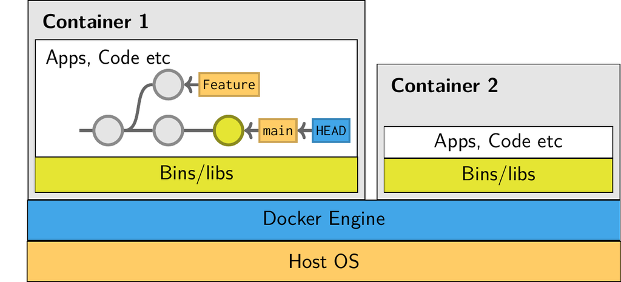

## 3.1 Simple overview

1. **Create a Docker definition file.**

   The `Dockerfile` contains a set of instructions that Docker uses to build your container with the correct specifications. For now you do not need to know all the bits and pieces here (though please see this [link](https://docs.docker.com/develop/develop-images/dockerfile_best-practices/) for a more in-depth understanding of what the Dockerfile is capable of).

   Lets start with a very simple `Dockerfile` (which should be a plain text file located in the root of a project directory). This first example will be a very minimal example and much of the rest of the Docker section of this tutorial will then progressively build on this example to introduce more and more complexity.

   The image we will build will start with a very minimal Debian Linux base called [minidep](https://hub.docker.com/r/bitnami/minideb) sourced from Dockerhub. This provides a fully functioning Linux operating system complete with the typical terminal power tools.

   To then extend the image by updating the package lists (location of repositories) before adding (installing) a small fun terminal application (cowsay) that generates ASCII art of a cow (or other animals) along with a speech bubble.

   ```
   FROM bitnami/minideb:bookworm
   LABEL maintainer="Author"
   LABEL email="author_email@email.com"

   ## Install the os packages
   RUN apt-get update \
     && apt-get install -y --no-install-recommends \
       cowsay \
     && rm -rf /var/lib/apt/lists/*
   ```

   In a terminal in the same location as the `Dockerfile` (i.e. your *sandpit folder*), enter something the following:

   ```bash
   docker build . --tag minideb
   ```

   where:
   - `.` indicates that the path used for the build context (in this case the current working directory - `.` means current location). Any files within this path can be copied into the image or used in the build context (for example, a `Dockerfile`).
   - `--tag minideb` provides a name (and optionally, a tag) for the image (in this case `minideb`). The name (and tag) can be anything, yet should be descriptive enough to help you distinguish this container image from other container images that you might construct on your system.

   This will build a series of docker container images (each of the layers built upon the layer before) in a local registry

   **More details**

   Usage: `docker build [OPTIONS] PATH | URL | -`  
   Common options:

   | Name | Description | Default |
   | --- | --- | --- |
   | `--file, -f` | Path and name of `Dockerfile` | `Dockerfile` |
   | `--no-cache` | Do not use cache when building image |  |
   | `--tag, -t` | Name (and optional tag) in `name:tag` format |  |

   Typical files in context:
   - `Dockerfile`: a build recipe file
   - `.dockerignore`: similar to a `.gitignore`, this file lists files to be ignored in collating the files that form the build context.

   As an alternative to providing build instructions in the form of a `Dockerfile`, build can accept a `URL` to a (remote) docker repository.  
   More info:  
   https://docs.docker.com/engine/reference/commandline/build/
3. **Check that the image(s) have been created**

   A list of images in your registry is obtained by:

   ```bash
   docker image ls
   ```

   ```
   REPOSITORY                                   TAG        IMAGE ID       CREATED        SIZE
   minideb                                      latest     0cd4e543915d   1 second ago   121MB
   ghcr.io/pcinereus/suyrs_documents            latest     6768d0f29c7d   25 hours ago   10.2GB
   bitnami/minideb                              bookworm   f29455a5e33f   6 days ago     120MB
   ghcr.io/dependabot/dependabot-updater-core   latest     bf54b2c91cec   7 days ago     794MB
   ```

   Note, the above simply lists all named images in your local registry. To get a more complete list of all images:

   ```bash
   docker images -a
   ```

   ```
   REPOSITORY                                   TAG        IMAGE ID       CREATED         SIZE
   minideb                                      latest     0cd4e543915d   1 second ago    121MB
   <none>                                       <none>     b748b86535e4   4 seconds ago   120MB
   <none>                                       <none>     c1d5735bf5b4   5 seconds ago   120MB
   ghcr.io/pcinereus/suyrs_documents            latest     6768d0f29c7d   25 hours ago    10.2GB
   bitnami/minideb                              bookworm   f29455a5e33f   6 days ago      120MB
   ghcr.io/dependabot/dependabot-updater-core   latest     bf54b2c91cec   7 days ago      794MB
   ```

   The `-a` switch indicates all images (including unnamed and hanging images).

   This list appears chronologically from bottom to top. Hence, the Dockerhub image (`bitnami/minideb`) appears at the bottom of this list and above this there is a succession of intermediate images that correspond to each of the layers defined in the `Dockerfile`. Note, each successive image is progressively larger in size as the layer incorporates the layer below. At the top of the list is the full container image (with `latest` tag).

   Importantly, while we have built a container image, we do not yet have any running containers. We can demonstrate this by listing all existing containers:

   ```bash
   docker ps -a
   ```

   ```
   CONTAINER ID   IMAGE                                      COMMAND                  CREATED          STATUS          PORTS     NAMES
   ....
   ```

   The output is empty (assuming you have not previously generated any containers), indicating that there are currently no running containers.
4. **Test the docker image (fire up an ephemeral container)**

   We will now test the image by generating and running a container from our container image. Once the container has started, the `cowsay` terminal application will display an ASCII cow saying ’Moo” before quietly terminating. The container will be automatically stopped and removed.

   ```bash
   docker run --entrypoint ./usr/games/cowsay --rm minideb Moo
   ```

   ```
    _____
   < Moo >
    -----
           \   ^__^
            \  (oo)\_______
               (__)\       )\/\
                   ||----w |
                   ||     ||
   ```

   where:
   - `--entrypoint ./usr/games/cowsay` defines the base command that will be run once the container has started. In this case, it specifies the full path to the `cowsay` executable file.
   - `--rm` indicates that the container should be removed after it has finished running.
   - `minideb` is the name of our docker container image
   - `Moo` is the string passed on to `cowsay` to display in the speech bubble. Feel free to experiment with other strings here.

   To further appreciate the way arguments are passed on to applications within a container, lets alter the `cowsay` animal.

   ```bash
   docker run --entrypoint ./usr/games/cowsay --rm minideb -f /usr/share/cowsay/cows/koala.cow Grunt
   ```

   ```
    _______
   < Grunt >
    -------
     \
      \
          ___
        {~._.~}
         ( Y )
        ()~*~()
        (_)-(_)
   ```

   In the above example, we passed `-f /usr/share/cowsay/cows/koala.cow Grunt` on to `cowsay`. In this context, `-f` points to were alternative animal definitions are located.
5. **Test the docker image interactively**

   Rather than fire up a container, run some command and then immediately terminate, it is possible to run a container in *interactive mode*. In this mode, after the container starts up, you will be placed in a terminal where you can issue any available command you like. Once you have finished the interactive session, simply enter `exit` and the container will then terminate.

   Try the following (within the container):

   ```bash
   docker run --rm -it minideb
   ```

   Once the prompt appears try entering the following:
   - list the files and folders in the current working directory

   ```bash
   ls -la
   ```

   - run the cowsay application

   ```bash
   ./usr/games/cowsay Moo
   ```

   - exit the container

   ```bash
   exit
   ```

   Running in interactive mode is very useful when developing/debugging code on a container.

## 3.2 Some Dockerfile goodness

**Incorporate default commands**

Lets now step this up a bit and add some more information to the build recipe. Rather than alter the previous `Dockerfile`, we will instead make a different file (`Dockerfile2`) and inform `docker` to build with this alternative `Dockerfile`.

```
FROM bitnami/minideb:bookworm
LABEL maintainer="Author"
LABEL email="author_email@email.com"

## Install the os packages
RUN apt-get update \
  && apt-get install -y --no-install-recommends \
    cowsay \
  && rm -rf /var/lib/apt/lists/*

## Default command to run
ENTRYPOINT ["/usr/games/cowsay","-f","/usr/share/cowsay/cows/koala.cow"]

## Default extra parameters passed to the command
CMD ["Grunt"]
```

In the above `Dockerfile`:

- `ENTRYPOINT` provides a default command to run within the container. This specification is in *JSON* format.
- `CMD` provides default extra parameters that are passed on to the command (also in *JSON* format). This can be overridden by passing an alternative when running the `docker run` command (see below).

If we now build our container image using this `Dockerfile2`:

```bash
docker build . --tag minideb -f Dockerfile2
```

If we again review the list of images, we see that there are now two additional intermediate images and the `latest` image has been updated.

```bash
docker images -a
```

```
REPOSITORY                                   TAG        IMAGE ID       CREATED         SIZE
minideb                                      latest     9ccce9004868   1 second ago    121MB
<none>                                       <none>     cd5f94303e66   2 seconds ago   121MB
<none>                                       <none>     0cd4e543915d   3 seconds ago   121MB
<none>                                       <none>     b748b86535e4   6 seconds ago   120MB
<none>                                       <none>     c1d5735bf5b4   7 seconds ago   120MB
ghcr.io/pcinereus/suyrs_documents            latest     6768d0f29c7d   25 hours ago    10.2GB
bitnami/minideb                              bookworm   f29455a5e33f   6 days ago      120MB
ghcr.io/dependabot/dependabot-updater-core   latest     bf54b2c91cec   7 days ago      794MB
```

We can now run the container as:

```bash
docker run --rm minideb
```

```
 _______
< Grunt >
 -------
  \
   \
       ___
     {~._.~}
      ( Y )
     ()~*~()
     (_)-(_)
```

To override the default arguments (**CMD**) we baked into the docker image, we can issue an alternative as a command line argument.

```bash
docker run --rm minideb Meow
```

```
 ______
< Meow >
 ------
  \
   \
       ___
     {~._.~}
      ( Y )
     ()~*~()
     (_)-(_)
```

**Copy and mountpoints**

So far, we have used the docker container to display an ASCII art cow (or koala) in the terminal and then exit. Whilst, this might have some utility as a simple example of interacting with containers, it hardly represents typical work.

In the context of reproducible research, containers are useful for providing a consistent environment in which to run code. Thus in order to be useful, a container should have:

1. access (or a copy) of the code within the container
2. the ability to store the results on the host where they can be viewed and disseminated.

To illustrate these, we will add the R Statistical and Graphical Environment to our container image and use this in two further examples.

#### Copy

For the first example, we will add instructions to the `Dockerfile` to copy a small R script (lets call it `analysis.R`) into the container so that the code can be run within the container environment. Lets create two files:

```
dat <- data.frame(y = rnorm(10))
dat
write.csv(dat, file = "dat.csv", row.names = FALSE)
```

- a `Dockerfile` called `Dockerfile3`

```
FROM bitnami/minideb:bookworm
LABEL maintainer="Author"
LABEL email="author_email@email.com"

## Install the os packages
RUN apt-get update \
  && apt-get install -y --no-install-recommends \
    r-base \
  && rm -rf /var/lib/apt/lists/*

COPY analysis.R ~/
WORKDIR ~/

## Default command to run
ENTRYPOINT ["Rscript"]

## Default command parameters
CMD ["analysis.R"]
```

This `Dockerfile` includes instructions to:

```
- install R (`r-base`)

- copy our R script from the current working directory to the home
  folder in the container (`COPY analysis.R ~/`)

- set the working directory within the container to be the home
  folder (`WORKDIR ~/`)

- specify that once the container has started, the `Rscript`
  command should be run (`ENTRYPOINT ["Rscript"]`)

- specify that once the container has started, the `Rscript`
  command should be run using the `analysis.R` script
  (`CMD ["analysis.R"]`)
```

Great. This time when we build the container image, we will provide both a name and tag for the image (via `--tag r:1`). This will result in an image called `r` with a tag of `1`.

```bash
docker build . --tag r:1 -f Dockerfile3
```

When we run this new image, we see that a data frame of 10 values is returned to the terminal.

```bash
docker run --rm r:1
```

```
             y
1   1.12313736
2  -0.73923054
3  -0.01971826
4   1.16538673
5   1.31791918
6   0.79564219
7   0.63659791
8  -0.35060425
9   2.53486637
10  0.72491299
```

#### Mount points

R did indeed run the `analysis.R` script inside the container. However, what happened to the file containing the exported data (`dat.csv`)? Although this file was created inside the container, it was completely lost when the container terminated. Obviously that is not that useful.

For the second example, rather than copy the R script to the container, we will instead mount a local folder to a point within the container. That way we can access select host files and folders within the container, thereby enabling us to both read the R script directly and write out any output files.

To support this, we will create another `Dockerfile` (`Dockerfile4`).

```
FROM bitnami/minideb:bookworm
LABEL maintainer="Author"
LABEL email="author_email@email.com"

## Install the os packages
RUN apt-get update \
  && apt-get install -y --no-install-recommends \
    r-base \
  && rm -rf /var/lib/apt/lists/*

WORKDIR /home/Project

## Default command to run
ENTRYPOINT ["Rscript"]

## Default command parameters
CMD ["analysis.R"]
```

The changes from the previous `Dockerfile`:

- remove the `COPY` statement as we will not need to work on a copy of the R code, we can work on it directly.
- change the container working directory to `/home/Project` - Note, this path will not exist and will be created.

We will now build the container image with the name:tag of `r:2`

```bash
docker build . --tag r:2 -f Dockerfile4
```

This time, when we run the container image, we will indicate a volume to mount (and a folder to mount this volume to). This will define which host folder to mount (map) and the path to mount this to within the container.

A bit more

```bash
cd ~/tmp/docker_tests/
ls -lat
docker run --rm -v $(pwd):/home/Project r:2
```

```
            y
1   0.1066244
2   1.5232261
3  -0.7750786
4  -1.4771543
5  -1.6383496
6  -0.4244388
7  -1.2385897
8   1.6335093
9   1.3878943
10 -0.4548697
```

where:

- `-v pwd:/home/Project` defines the mounting of the current working directory on the host machine to the `/home/Project' (which the`Dockerfile` defined as the working directory) folder inside the container

If we list the contents of our local folder, we see that the output file (`dat.csv`) has been created on the host filesystem.

```bash
cd ~/tmp/docker_tests/
ls -la
```

```
total 16
-rw-r--r--  1 root root  182 Mar  4 01:27 dat.csv
drwxr-xr-x  2 root root 4096 Mar  4 01:27 .
-rw-r--r--  1 root root   89 Mar  4 01:27 analysis.R
drwxr-xr-x 11 1001 1001 4096 Mar  4 01:27 ..
```

Of course, it is possible to define a combination of the above two examples - one in which a copy of the codebase is packaged up into the container image (to ensure that a specific codebase is always applied), yet a moutpoint is also specified at run time to enable the output(s) to be obtained by the host.

**.dockerignore**

The `.dockerignore` file is similar in structure to a `.gitignore` file in that they both define files (or patterns) to ignore. The purpose of a `dockerignore` is to indicate which files and folders should be **excluded** from the docker build context. Excluding certain files and directories:

- reduce image size by preventing unnecessary files from being copied (e.g., logs, temporary files).
- speed up builds by avoiding sending large or irrelevant files to the Docker daemon.
- improve security by excluding sensitive files like `.env` or credentials

## 3.3 Building a reproducible R environment

Just as it might be important to be able to recreate the state of an operating system and software from a previous time (to maximise the potential for reproducibility), it might be equally important to ensure that the entire environment reflects this state back in time. In the case of R software, this means that all included *packages* should be the same versions that were available at that previous time.

Posit (the developers of Rstudio) provide daily snapshots of CRAN ([Posit package manager](https://packagemanager.posit.co/)). We can therefore nominate a date when providing package installation instructions in a `Dockerfile`.

On UNIX based systems, such as linux and MacOSX, many R packages need to be compiled from source during their installation. As such, they sometimes have additional external system dependencies. Normally, it it is necessary to install these external dependencies prior to attempting to install the R packages. This is done via the `apt-get install` (debian) instructions in the Dockerfile. Unfortunately, this can turn into a very iterative process or attempting to install an R package, examine the progress and look out for any errors about missing dependencies and going back to the Dockerfile and adding the appropriate dependencies before trying again.

The R package called `pak` is designed to install R packages and if necessary handle the installation of any additional external dependencies as well. This makes `pak` a very useful addition in Dockerfiles.

Some R packages have system dependencies that usually must be installed before attempting to install R packages.

For this example, we will start from an image that already has a version of R (4.2.2) built in (`rocker/r-ver:4.2.2`). Although this image is substantially larger than the mini debian we used earlier, it does come with all the build tools and R, each of which would otherwise require additional downloads and compilation. The net result is that the `rocker/r-ver:4.2.2` image requires less overall download traffic than the individual parts.

**Note**

Note, this image will take substantially longer to make as it not only has to pull down a larger base, it then has to compile the entire tidyverse from source.

The changes from the previous `Dockerfile`:

- switch the base image to `rocker:r-ver:4.2.2`
- add numerous `-dev` developer package dependencies
- install the `tidyverse` collection of packages from a dated snapshot

```
FROM rocker/r-ver:4.2.2
LABEL maintainer="Author"
LABEL email="author_email@email.com"

RUN apt-get update \
  && apt-get install -y --no-install-recommends \
  libxml2-dev \
  libcurl4-openssl-dev  \
  libssl-dev \
  zlib1g-dev \
  && rm -rf /var/lib/apt/lists/*

## Install R package versions from Posit package manager (based on a date - YYYY-MM-DD)
RUN R -e "options(repos = \
    list(CRAN = \"https://packagemanager.posit.co/cran/2024-01-10/\")); \
  install.packages(\"pak\"); \
"
RUN R -e "options(repos = \
    list(CRAN = \"https://packagemanager.posit.co/cran/2024-01-10/\")); \
  pak::pkg_install(c(\"tidyverse\")); \
"

WORKDIR /home/Project

## Default command to run
ENTRYPOINT ["Rscript"]

CMD ["analysis.R"]
```

**Note**, many of the large collection of R packages targeted for install as part of the `tidyverse` ecosystem (or its dependencies) require full compilations. Whilst this does help ensure that the underlying package routines are optimised for your system, the entire install process may take up to an hour. This installation can be sped up substantially by instead installing a pre-bundled version of the `tidyverse` packages (and dependencies) directly from the Ubuntu repositories. The associated alternative `Dockerfile` is provided in the following expandable section.

**Alternative Dockerfile**

As an alternative, we could instead install tidyverse from the ubuntu r-cran repository. This install will be far faster, yet likely not as up-to-date and we would have a little less control over exactly which version we were installing…

```
FROM rocker/r-ver:4.2.2
LABEL maintainer="Author"
LABEL email="author_email@email.com"

RUN apt-get update \
  && apt-get install -y --no-install-recommends \
  r-cran-tidyverse \
  && rm -rf /var/lib/apt/lists/*

WORKDIR /home/Project

## Default command to run
ENTRYPOINT ["Rscript"]

CMD ["analysis.R"]
```

We will now build the container image with the name:tag of `r-tidyverse:1` Note, this will take some time to complete.

```bash
docker build . --tag r-tidyverse:1 -f Dockerfile5
```

If we now run `docker` with this image, the resulting container will automatically run a non-interactive session using the `analysis.R` script.

```bash
cd ~/tmp/docker_tests/
docker run --rm -v `pwd`:/home/Project r-tidyverse:1
```

```
             y
1  -1.83386021
2   1.47401484
3   0.96953368
4  -0.38088135
5   0.86383031
6   0.94533899
7  -0.51069732
8  -1.28245445
9   0.05576938
10 -1.75212272
```

where:

- `-v pwd:/home/Project` defines the mounting of the current working directory on the host machine to the `/home/Project' (which the`Dockerfile` defined as the working directory) folder inside the container

Conveniently, we can override the **CMD** command when we run `docker run`. In the current context, perhaps we would like to run the R session on an different R script. Lets try this by creating a new R script - this time, one that makes use of the `tidyverse` ecosystem.

```
library(tidyverse)
dat <- data.frame(y = rnorm(10))
dat
dat %>% summarise(Mean = mean(y), Median = median(y))
```

Now we can nominate this alternative R script as the argument to the `Rscript` command.

```bash
cd ~/tmp/docker_tests/
docker run --rm -v `pwd`:/home/Project r-tidyverse:1 analysis5.R
```

```
              y
1   0.531989250
2  -0.004360166
3  -0.124019943
4  -2.457102952
5  -1.417995358
6  -0.308157149
7  -0.313371284
8  -0.252866200
9   0.593289251
10  1.261749913
        Mean     Median
1 -0.2490845 -0.1884431
```

## 3.4 Managing Docker images

**Listing images**

To list the most recently created images.

```bash
docker images
```

```
REPOSITORY                                   TAG        IMAGE ID       CREATED         SIZE
r-tidyverse                                  1          49ddda8c0ae2   2 seconds ago   2.1GB
r                                            2          f2ded2eef935   7 minutes ago   289MB
r                                            1          83867bf47d0e   7 minutes ago   289MB
minideb                                      latest     9ccce9004868   8 minutes ago   121MB
ghcr.io/pcinereus/suyrs_documents            latest     6768d0f29c7d   25 hours ago    10.2GB
bitnami/minideb                              bookworm   f29455a5e33f   6 days ago      120MB
....
```

The output will include all created images along with the base images that they are derived from (those sourced from Dockerhub for example).

The images (`REPOSITORY`) entries that are `<none>` are *dangling* images. That is, they are intermediate images that were previously used in the building of an image and are no longer used (because the `Dockerfile` layer that they were associated with is no longer used in the latest version of that `Dockerfile`).

We can exclude them from the output, by defining a filter that excludes dangling images.

```bash
docker images -f "dangling=false"
```

```
REPOSITORY                                   TAG        IMAGE ID       CREATED         SIZE
r-tidyverse                                  1          49ddda8c0ae2   2 seconds ago   2.1GB
r                                            2          f2ded2eef935   7 minutes ago   289MB
r                                            1          83867bf47d0e   7 minutes ago   289MB
minideb                                      latest     9ccce9004868   8 minutes ago   121MB
ghcr.io/pcinereus/suyrs_documents            latest     6768d0f29c7d   25 hours ago    10.2GB
bitnami/minideb                              bookworm   f29455a5e33f   6 days ago      120MB
....
```

If instead of `dangling=false`, you indicate `dangling=true`, only dangling images are displayed. This can be useful for identifying redundant images.

Another useful filter is to predicate on time relative to an image. For example, to display all images that were created *since* `minideb`:

```bash
docker images -f "since=minideb"
```

```
REPOSITORY    TAG       IMAGE ID       CREATED         SIZE
r-tidyverse   1         49ddda8c0ae2   2 seconds ago   2.1GB
r             2         f2ded2eef935   7 minutes ago   289MB
r             1         83867bf47d0e   7 minutes ago   289MB
```

There is also a *before* version.

Note, the above examples will exclude the intermediate images that are associated with build layers. If we want to see all images (including the intermediate images), use the `-a` switch.

```bash
docker images -a
```

```
REPOSITORY                                   TAG        IMAGE ID       CREATED         SIZE
r-tidyverse                                  1          49ddda8c0ae2   2 seconds ago   2.1GB
<none>                                       <none>     906ecee6e008   3 seconds ago   2.1GB
<none>                                       <none>     05c895b63d03   5 seconds ago   2.1GB
<none>                                       <none>     32b81bcb178f   7 seconds ago   2.1GB
<none>                                       <none>     c70efe2718de   6 minutes ago   918MB
<none>                                       <none>     6faaa326f640   7 minutes ago   910MB
....
```

**Removing images**

**Removing all unused images**

This will also remove unused (dangling) containers, volumes and caches.

```bash
docker system prune
```

**Removing all images**

```bash
docker system prune -a
```

**Removing specific images**

```bash
docker rmi <ID>
```

where `<ID>` is the `IMAGE ID` from `docker images -a`

**Removing images (regex)**

```bash
docker images -a | grep <"pattern"> | awk '{print $3}' | xargs docker rmi
```

where `<"pattern">` is a regular expression for isolating the name of the image(s) to remove.

**remove dangling images**

```bash
docker rmi -f $(docker images -f "dangling=true" -q).
```

# 4 Generating docker images on github

Up to now, the docker images we have created have been housed in a registry locally on the machine that we are building them on. In the spirit of reproducibility, we ideally want these images to be available to others (as well as our future selves). There are numerous options for making images available:

- each user (or your future self) can build the image from the `Dockerfile`. In many cases, this will be a lengthy (yet automated) process. For this to be a viable option, each party will need to have the ability and resources to be able to build docker images from a Dockerfile.
- the docker image could be hosted on a remote repository (such as dockerhub). This option requires that the original author of the docker image has a dockerhub account so that they can push the image that they created locally up to the remote registry.
- build and host the docker image on github. This option requires the original author/authors to have a github account.

Building Docker images on GitHub via GitHub Actions is useful because it enables automated, consistent, and reproducible builds directly from your remote repository. As such, it is possible to trigger a fresh image build every time there is a change to the repo itself. This reduces manual effort and minimizing deployment errors. With GitHub Actions, you can integrate CI/CD workflows, automatically test images, and push them to container registries (e.g., GitHub Container Registry or Docker Hub). It also enhances collaboration, as team members can track build logs, detect failures early, and enforce security best practices through automated vulnerability scanning. Finally, it also means that the one platform can be used to host both code and the environment in which to run the code.

To have Github Actions build and publish a docker image, we start by creating a github actions workflow file. This file is in yaml format and should be placed a directory called `.github/workflows` within your git repository.

```
name: Create and publish the Docker image

on:
 workflow_dispatch:
 push:
   branches: [ "main" ]

env:
  REGISTRY: ghcr.io
  IMAGE_NAME: ${{ github.repository }}

jobs:
  build-image:
    runs-on: ubuntu-latest

    if: "!contains(github.event.head_commit.message, '[ci skip]')"

    permissions:
      contents: read
      packages: write

    name: ${{ matrix.config.r }}

    strategy:
      fail-fast: false
      matrix:
        config:
        #- { r: devel }
        #- { r: next  }
        - { r: 4.4.1 }

    steps:
      - name: Checkout repository
        uses: actions/checkout@v4

      - name: Login to GitHub Container Registry
        uses: docker/login-action@v1
        with:
          registry: ${{ env.REGISTRY }}
          username: ${{ github.repository_owner }}  #
          password: ${{ secrets.GITHUB_TOKEN }}

      - name: Extract metadata (tags, labels) for Docker
        id: meta
        uses: docker/metadata-action@9ec57ed1fcdbf14dcef7dfbe97b2010124a938b7
        with:
          images: ${{ env.REGISTRY }}/${{ env.IMAGE_NAME }}

      - name: Build and push Docker image
        uses: docker/build-push-action@v5
        with:
          context: .
          push: true
          tags: ${{ steps.meta.outputs.tags }}
          labels: ${{ steps.meta.outputs.labels }}
```

Now any time there is a change to the main branch, the image will be rebuilt and published to Github Container Registry.

To access the built image:

- navigate to the `Code` panel of the repositories Github page.
- click on the item under the heading `Packages`.

[figure not shown]

The displayed panel will provide information on the versions of the package available as well as instructions on how to obtain (pull) the image to a local repository from where it can be run.

The end